# Apresentação e Curadoria de Dados

github.com/nacmarino/maR

## *Big data*: o futuro da ecologia

- Os dados são centrais em qualquer tipo de pesquisa que seja realizada;
- No cenário atual, existe grande facilidade para armazenagem e acesso à qualquer tipo de dado;
- Integração da evidência disponível é essencial, e será cada vez mais importante no mundo em que viveremos;
- *Big data*: faz referência ao volume massivo de dados que não são manuseados por ferramentas usuais de análise de dados (*ver mais na disciplina de Introdução à Programação em R*), e que compõem uma oportunidade sem precedente para o avanço da ciência, teórica e aplicada;
- Maior parte dos estudos ecológicos são difíceis de serem repetidos (escala temporal e espacial, eventos raros, acesso aos locais,…): **replicagem e reproducibilidade**?

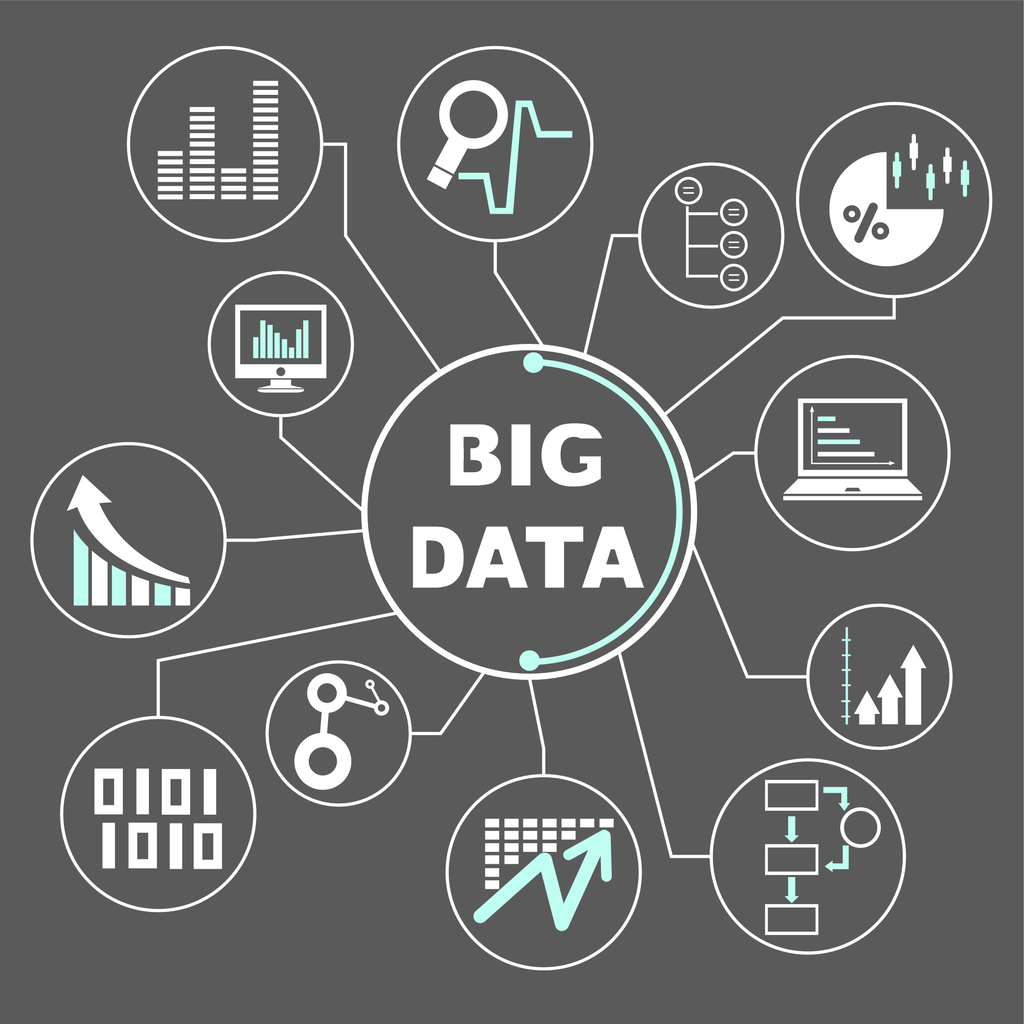

## A crise de reproducibilidade

- Você é capaz de reproduzir o achado de um trabalho que foi publicado - da produção do dado à sua análise?

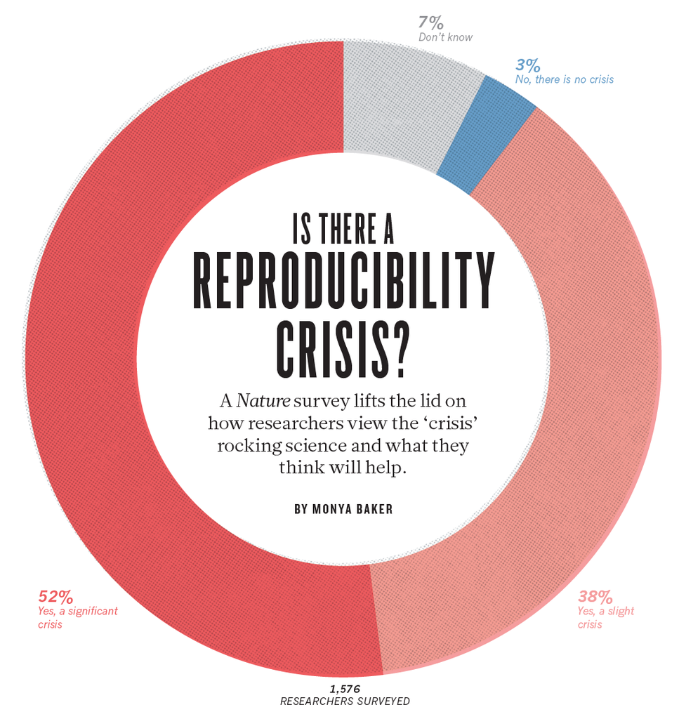

Fonte: Baker & Penny, 2016, Nature, Is there a reprodubility crisis

## A crise de reproducibilidade

- Não é tanto um problema do desenho do estudo, mas sim **o que você tira dele** e **como**.

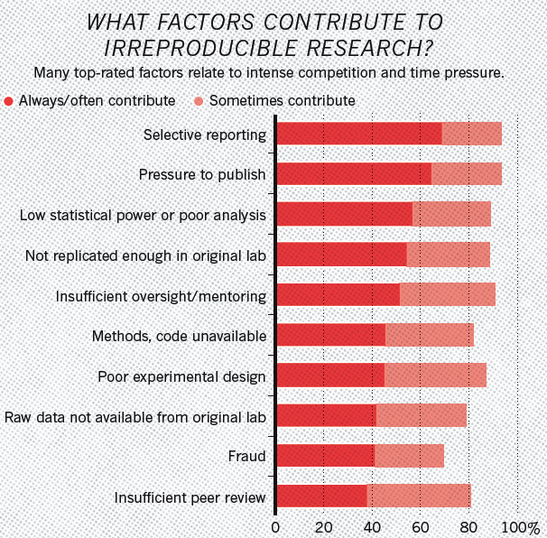

Fonte: Baker & Penny, 2016, Nature, Is there a reprodubility crisis

## Regra de Ouro (que ninguém comenta)

- **Integridade Científica** (Richard P. Feynman, Cargo Cult Science): tentar fornecer todos os detalhes e informações para ajudar as outras pessoas à julgar o valor da sua contribuição, e não só a informação que o conduziu ao julgamento em uma direção ou outra.
  - Detalhes que podem introduzir dúvida na sua contribuição: evidência contra e a favor da sua hipótese;
  - Fatos que podem tornar sua contribuição inválida: outras causas que podem explicar seus resultados, artefatos que podem existir no seu trabalho;
  - Qual a evidência sustenta os fatos apresentados pelo seu trabalho: as suas análises estão fazendo direito o que você acha que elas estão fazendo?
  - As implicações do seu trabalho estão enraizadas nos fatos que ele demonstra ou você está tirando coelho da cartola/usando fogos de artifício/fazendo maquiagem?
  - Qual o limite da especulação?
- A ideia é assumir que você está errado, tentar enumerar razões para isso, e buscar invalidar todas elas.

Ainda do Feynman: "The first principle is that you must not fool yourself – and you are the easiest person to fool".

## Os maiores desafios em uma RS/MA

- **Falta de clareza**: estudos apresentam seu desenho de forma nebulosa;
- **Machismo estatístico às avessas**: Análises estatísticas não são conduzidas de forma convencional;
- **É só display**: Sumários estatísticos dos dados não são apresentados, apenas resultados estatísticos;
- **Apresentação seletiva de resultados**: dados são apresentados, mas não seguem o desenho amostral;
- **Bomba de fumaça**: reporta 10<sup>*n*</sup> resultados, que tem pouco haver com a hipótese do trabalho;
- **Mágico de Oz**: conclusões têm pouco haver (ou nada haver) com os resultados apresentados.

## Mudança de Perspectiva

## Re-uso dos dados

## Re-uso das conclusões

## Transparência: Seleção de Estudos

## Transparência: Extração de Dados

## Transparência: Análise de Dados

## Transparência: Interpretação dos Resultados

## Transparência: Conclusões

## Resumindo

## Literatura Recomendada

1. Baker & Penny, 2016, Nature, Is there a reprodubility crisis
2. Borer et al, 2009, Bull Ecol Soc Am, Some simple guidelines for effective data management
3. Elison, 2010, Ecology, Repeatability and transparency in ecological research
4. Hampton et al, 2013, Front Ecol Evol, Big data and the future of ecology
5. Parker et al, 2016, Ecol Lett, Promoting transparency in evolutionary biology and ecology
6. Zimmerman, 2008, Sci Tech Human Val, New knowledge from old data - the role of standards in the sharing and reuse of ecological data
7. Rothstein et al, 2013, Quality standards for research syntheses, In: Handbook of meta-analysis in ecology and evolution (Capítulo 20)
8. Lortie et al, 2013, Graphical presentation of results, In: Handbook of meta-analysis in ecology and evolution (Capítulo 21)
9. Richard P. Feynman, Cargo Cult Science: http://calteches.library.caltech.edu/51/2/CargoCult.htm